# Explore financial contribution of presidential election of California by Sándor Bordé

This dataset contains individual donations to the candidates of the Presidential Election in 2016. For each data entry, we have the amount of contribution, sender, the name of the candidate, date, note, etc. I have 1,304,346 entry in the dataset.

# Dataset description

```
## 'data.frame':    1304346 obs. of  18 variables:
##  $ cmte_id          : Factor w/ 25 levels "C00458844","C00500587",..: 6 6 6 15 7 15 7 7 7 6 ...
##  $ cand_id          : Factor w/ 25 levels "P00003392","P20002671",..: 1 1 1 23 12 23 12 12 12 1 ...
##  $ cand_nm          : Factor w/ 25 levels "Bush, Jeb","Carson, Benjamin S.",..: 4 4 4 23 20 23 20 20 20 4 ...
##  $ contbr_nm        : Factor w/ 231294 levels "0, J.","AABERG, RONALD D.",..: 7737 31589 70292 175046 117837 176412 119294 119294 119367 92318 ...
##  $ contbr_city      : Factor w/ 2534 levels "",".","1000 OAKS",..: 1130 320 726 1180 319 1903 1808 1808 2402 1072 ...
##  $ contbr_st        : Factor w/ 1 level "CA": 1 1 1 1 1 1 1 1 1 1 ...
##  $ contbr_zip       : Factor w/ 143656 levels "","00000","000090272",..: 115155 71795 53864 126927 66455 139488 17327 17327 45924 58804 ...
##  $ contbr_employer  : Factor w/ 65600 levels "","-","--","---",..: 38758 38758 38758 27559 4599 27559 62094 62094 41375 38758 ...
##  $ contbr_occupation: Factor w/ 28622 levels "","-","--","---",..: 21453 21453 21453 12691 23929 12691 17952 17952 19665 21453 ...
##  $ contb_receipt_amt: num  50 200 5 48.3 40 ...
##  $ contb_receipt_dt : Date, format: "16-04-26" "16-04-20" ...
##  $ receipt_desc     : Factor w/ 74 levels "","2016 SENATE PRIMARY DONOR REDESIGNATION FROM PRIMARY",..: 1 1 1 1 1 1 1 1 1 1 ...
##  $ memo_cd          : Factor w/ 2 levels "","X": 2 2 2 2 1 2 1 1 1 2 ...
##  $ memo_text        : Factor w/ 428 levels "","*","$0.02 REFUNDED ON 10/21/2016",..: 200 200 200 1 152 1 152 152 152 200 ...
##  $ form_tp          : Factor w/ 3 levels "SA17A","SA18",..: 2 2 2 2 1 2 1 1 1 2 ...
##  $ file_num         : int  1091718 1091718 1091718 1146165 1077404 1146165 1077404 1077404 1077404 1091718 ...
##  $ tran_id          : Factor w/ 1300659 levels "A000771210424405B8CF",..: 466737 466019 463401 852346 1037145 890424 1038589 1040890 1036607 466057 ...
##  $ election_tp      : Factor w/ 5 levels "","G2016","O2016",..: 4 4 4 2 4 2 4 4 4 4 ...
```

```
##       cmte_id            cand_id                            cand_nm
##  C00575795:688524   P00003392:688524   Clinton, Hillary Rodham  :688524
##  C00577130:407164   P60007168:407164   Sanders, Bernard         :407164
##  C00580100: 86258   P80001571: 86258   Trump, Donald J.         : 86258
##  C00574624: 57822   P60006111: 57822   Cruz, Rafael Edward 'Ted': 57822
##  C00573519: 27370   P60005915: 27370   Carson, Benjamin S.      : 27370
##  C00458844: 14095   P60006723: 14095   Rubio, Marco             : 14095
##  (Other)  : 23113   (Other)  : 23113   (Other)                  : 23113
##             contbr_nm              contbr_city     contbr_st
##  PETIT, MICHAEL  :    473   LOS ANGELES  :102710   CA:1304346
##  MITCHELL, MARCIA:    409   SAN FRANCISCO: 90937
##  SMITH, CHERYL   :    375   SAN DIEGO    : 46129
##  SAMATUA, DENISE :    373   OAKLAND      : 33235
##  CARROLL, TERI   :    352   SAN JOSE     : 30674
##  ADAM, MONIQUE   :    321   SACRAMENTO   : 23799
##  (Other)         :1302043   (Other)      :976862
##      contbr_zip           contbr_employer               contbr_occupation
##  92660    :    660   N/A          :185382   RETIRED              :260546
##  92037    :    565   RETIRED      :121569   NOT EMPLOYED         :115598
##  90049    :    495   SELF-EMPLOYED:120187   ATTORNEY             : 36640
##  92677    :    483   NONE         : 84297   INFORMATION REQUESTED: 30948
##  92067    :    474   NOT EMPLOYED : 50821   TEACHER              : 29104
##  911075001:    473   (Other)      :741411   (Other)              :831369
##  (Other)  :1301196   NA's         :   679   NA's                 :   141
##  contb_receipt_amt  contb_receipt_dt
##  Min.   :-10500.0   Min.   :13-11-05
##  1st Qu.:    15.0   1st Qu.:16-03-10
##  Median :    27.0   Median :16-05-31
##  Mean   :   116.2   Mean   :16-05-26
##  3rd Qu.:    88.0   3rd Qu.:16-09-13
##  Max.   : 10800.0   Max.   :16-12-31
##
##                                   receipt_desc     memo_cd
##                                         :1287456    :1104791
##  Refund                                 :  10413   X: 199555
##  REDESIGNATION FROM PRIMARY             :   1324
##  REDESIGNATION TO GENERAL               :   1324
##  REATTRIBUTION / REDESIGNATION REQUESTED:    569
##  REDESIGNATION TO CRUZ FOR SENATE       :    544
##  (Other)                                :   2716
##                                memo_text       form_tp
##                                     :776701   SA17A:1101230
##  * EARMARKED CONTRIBUTION: SEE BELOW:394270   SA18 : 192703
##  * HILLARY VICTORY FUND             :122912   SB28A:  10413
##  REDESIGNATION FROM PRIMARY         :  1324
##  REDESIGNATION TO GENERAL           :  1324
##  *BEST EFFORTS UPDATE               :  1256
##  (Other)                            :  6559
##     file_num                       tran_id        election_tp
##  Min.   :1003942   A5602AD777C8C4632B5A:      4        :  1695
##  1st Qu.:1077916   ADB49CB248C174E298F0:      4   G2016:483991
##  Median :1099613   A26C35A6066754130B99:      3   O2016:   632
##  Mean   :1102796   A340DF85B7F884133A20:      3   P2016:818021
##  3rd Qu.:1133832   A4E50E2DD07E4475996F:      3   P2020:     7
##  Max.   :1146285   A7C22FA389E0348F98F0:      3
##                    (Other)             :1304326
```

The dataset contains 1,304,346 contribution’s data; each entry has 18 variables.

# Data transformation

There are meaningless or not so informative variables:

- *cand_id*: this is redundant if we want to use the name of the candidate too.
- *contbr_st*: my dataset contains only data from CA, so it is meaningless.
- *memo_text*, *receipt_desc*: description of the receipt contains textual data which I won’t analyze. Besides that, in most cases this field is empty.
- *memo_cd*: this field only indicates that they provided any memo text.
- *form_tp*, *file_num*, *tran_id*: these variables serve only administrative purposes, but don’t provide any meaningful information.
- *contbr_zip*: this field deisgnates the contributor’s zip code. It would be too detailed so I exclude this variable from the analysis.

```
## [1] "cmte_id"           "cand_nm"           "contbr_nm"
## [4] "contbr_city"       "contbr_employer"   "contbr_occupation"
## [7] "contb_receipt_amt" "contb_receipt_dt"  "election_tp"
```

```
## [1] 0.01250665
```

In my dataset occurred some negative value (which means refund for the contributor) what I ignored because I wanted to look at the contribution. Negative values made up only the 1.2% of the whole dataset; so I decided to remove them from the further analysis.

# Univariate plots section

My primary interest is the distribution of the contribution amount along different factors. After plotting the amount distribution histogram, I found that there can be outliers which fall far from the most of the values. To see the distribution better, I adjusted the axis limits.

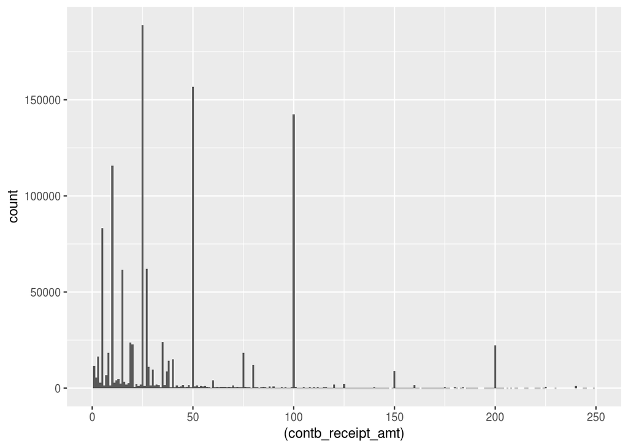

As we can see from the initial histogram, supporters tended to give specific amount of contribution like $5, $10, $50. But besides this fact, such a small binsize isn’t very informative; so I adjusted the histogram further.

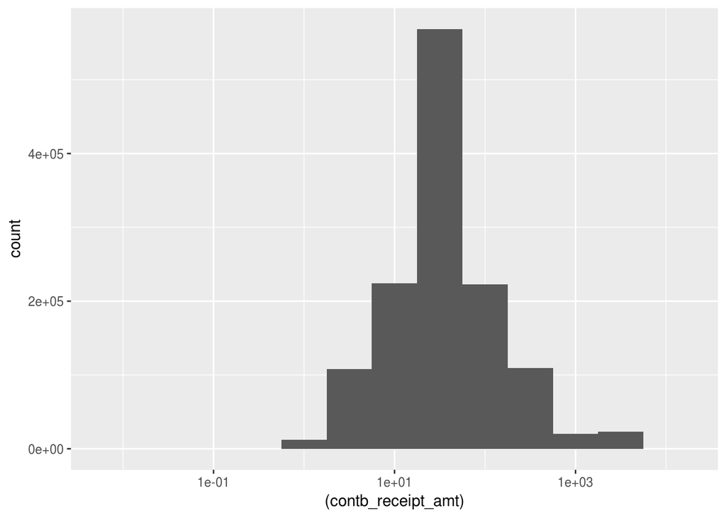

When I transformed the x-axis to log scale, I found that this dataset follows a long-tailed, log-normal distribution.

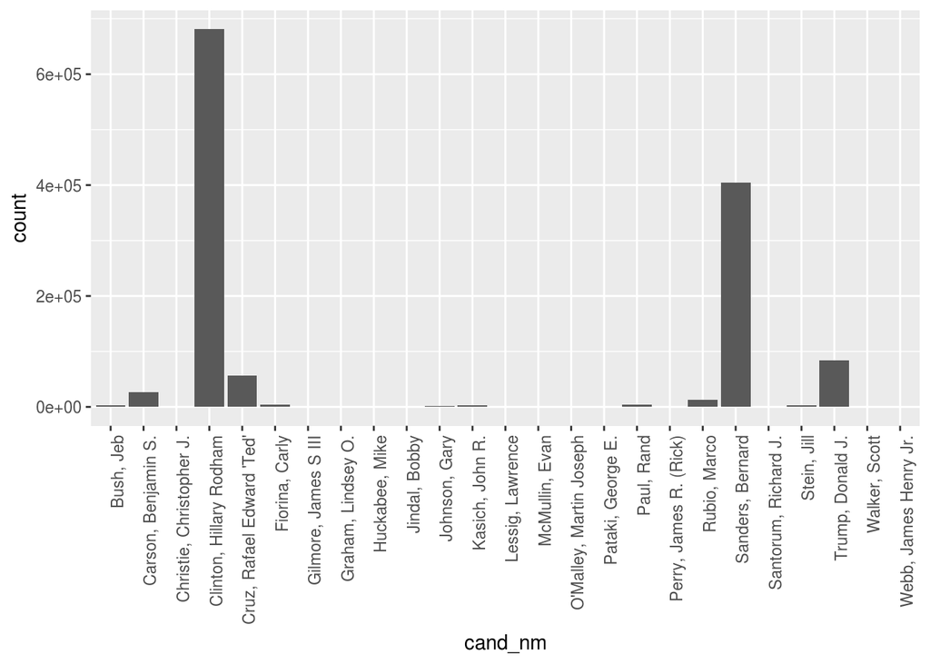

From the plot above we can see, that only a small fraction of the candidates received most of the contributions.

```
## # A tibble: 6 x 2
##   cand_nm                   cumulative_ratio
##   <fctr>                               <dbl>
## 1 Clinton, Hillary Rodham              0.529
## 2 Sanders, Bernard                     0.843
## 3 Trump, Donald J.                     0.908
## 4 Cruz, Rafael Edward 'Ted'            0.951
## 5 Carson, Benjamin S.                  0.972
## 6 Rubio, Marco                         0.982
```

We have 25 candidates in the dataset, but four of them received the 95% of the contributions.

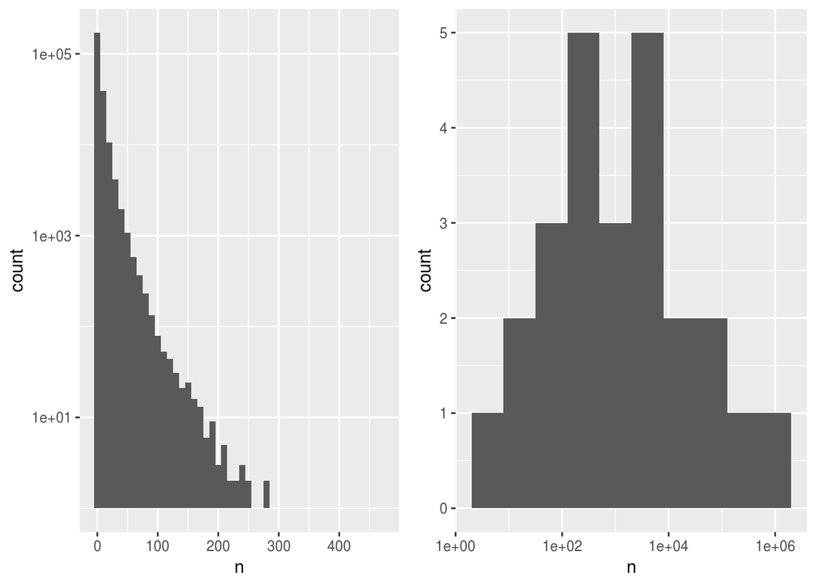

I have summed the number contributions per person. I can see that a very high portion supported the selected candidate only once. But, there is a couple of people who donated to his or her favorite candidate more than 200 times.

After counting the number of contributions by committees, I found that it follows a log-normal distribution. That is, most of the committees sent a few support, and some of them sent many times.

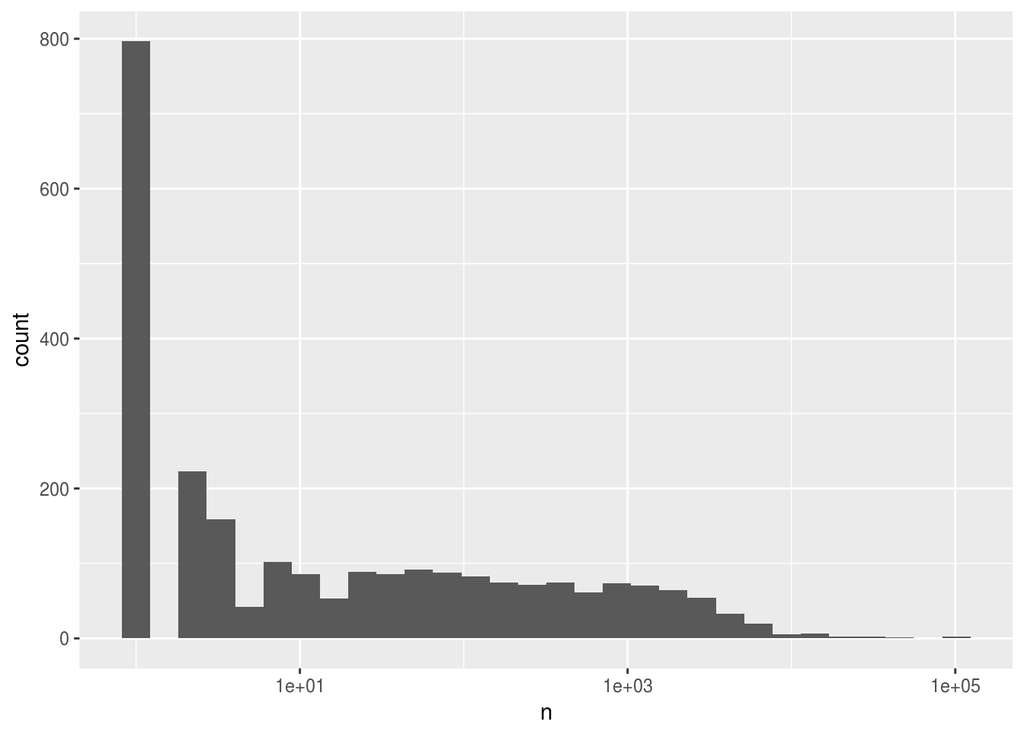

```
##     Min.  1st Qu.   Median     Mean  3rd Qu.     Max.
##      1.0      1.0      7.0    511.7    136.0 101500.0
```

We can see that this feature doesn’t follow log-normal, but long-tail distribution.

```
## # A tibble: 11 x 3
##    contbr_occupation          n  ratio
##    <fctr>                 <int>  <dbl>
##  1 RETIRED               258103 0.200
##  2 NOT EMPLOYED          115564 0.0897
##  3 ATTORNEY               36561 0.0284
##  4 INFORMATION REQUESTED  30912 0.0240
##  5 TEACHER                29040 0.0225
##  6 ENGINEER               17718 0.0138
##  7 HOMEMAKER              17101 0.0133
##  8 PHYSICIAN              16061 0.0125
##  9 SOFTWARE ENGINEER      15149 0.0118
## 10 PROFESSOR              14939 0.0116
## 11 CONSULTANT             13946 0.0108
```

In my dataset, there are 28622 different occupation type. But after counting the number of contribution, I found that only 11 occupation has at least 1% ratio, so it follows a long-tail distribution too.

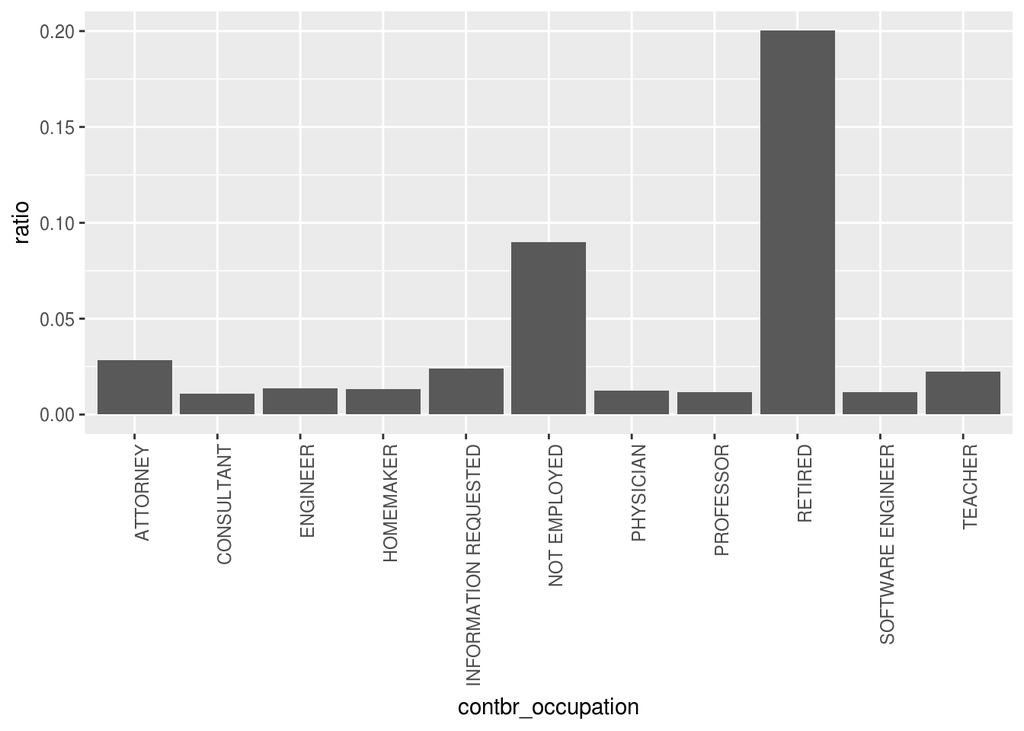

One interesting fact that about 20% of the contributions came from retirees, the second largest group (almost 10%) was the unemployed people. Besides that, most of the top 11 occupation was some white-collar job: attorney, consultant, engineer etc.

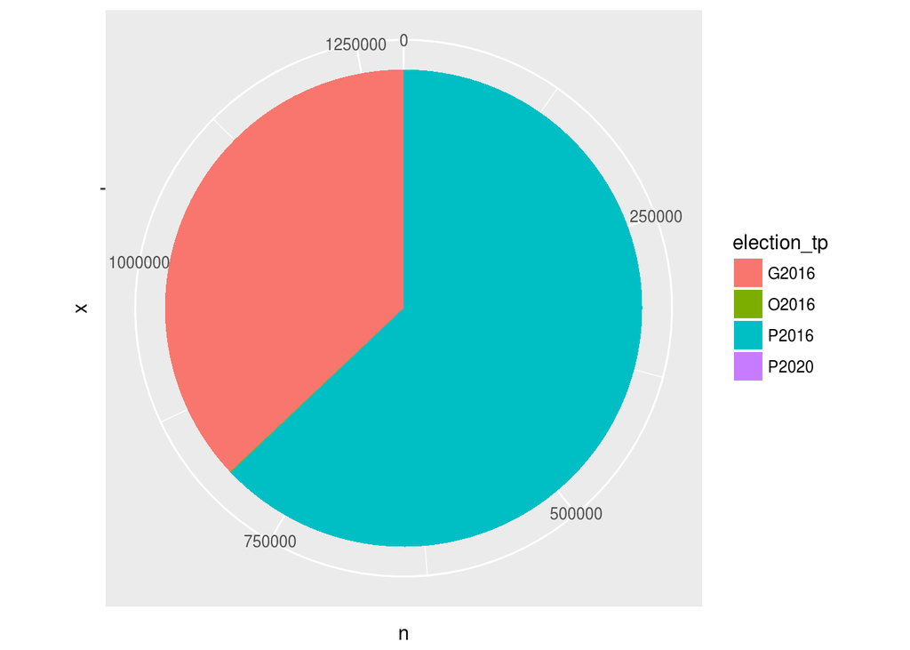

Almost every contribution have been made for the 2016 primary and general election. Because the other two (primary 2020 and other 2016) was so small I decided not to use them in the further analysis.

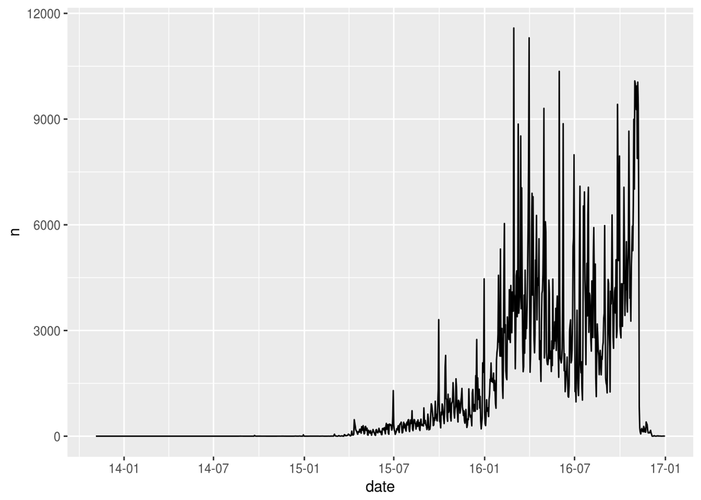

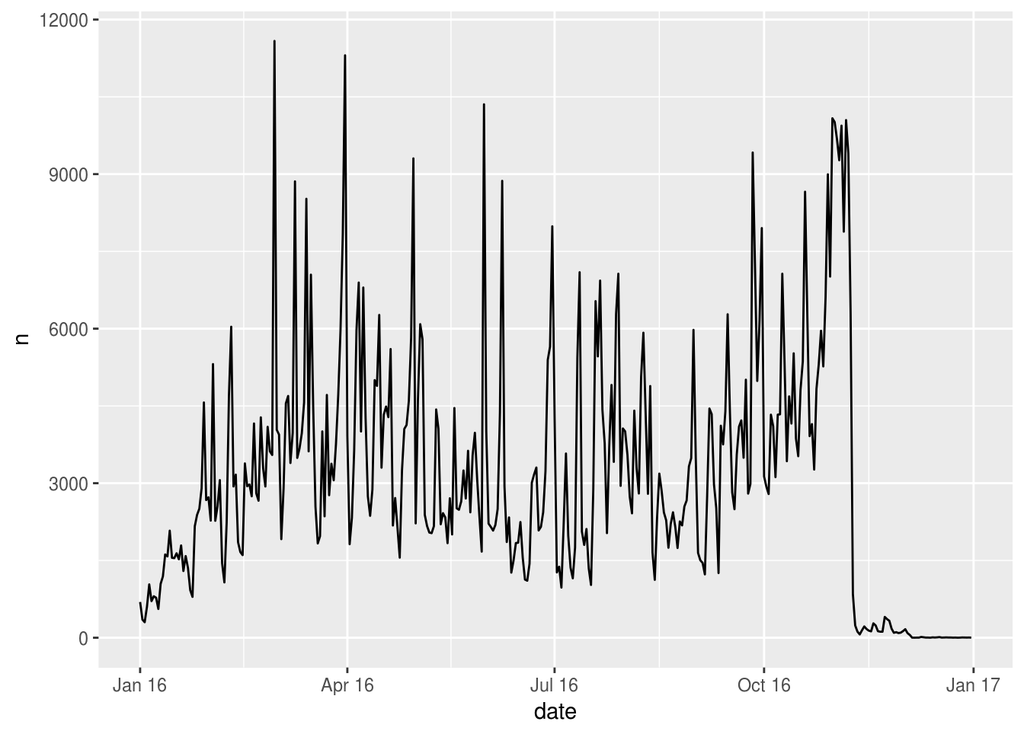

# Univariate Analysis

### What is the structure of your dataset?

Other observation:

- There are 25 candidates in the dataset, but four of them received the 95% of the contribution.
- 29% of the contributions came from retired or unemployed people.
- Most of the contributors made a small number of donation, but there were a few people who contributed more than 200 times.
- Most of the contributions were a small amount, and the amount per donation followed a log-normal distribution.

### What is/are the main feature(s) of interest in your dataset?

The main feature of interest for me is the amount of support per candidate. I would like to gain some insight and maybe predict, what kind of people supported which candidate. I will consider only the top 4 candidate because of their dominance in the dataset.

The other thing what I want to examine is the contribution for the two finalist in function of the date. Is there any trend in support?

### What other features in the dataset do you think will help support your investigation into your feature(s) of interest?

I will use the occupation, city, date and committee to make research my idea.

### Did you create any new variables from existing variables in the dataset?

I didn’t create any new variable in the dataset, but I created new grouped dataframes to count the number of contributions per different categories.

### Of the features you investigated, were there any unusual distributions? Did you perform any operations on the data to tidy, adjust, or change the form of the data? If so, why did you do this?

I log-transformed the distribution of the amount of support and the number of donations made by committees.

I removed the negative donation amounts because I wanted to examine only positive support without refunds. There were some values with 0 amount, I dropped those observations because it was meaningless too.

# Bivariate Plots Section

I want to answer a question using my analysis: “Who supported whom the most?” Therefore, I start with a bar chart displaying the sum of each contribution for each candidate.

One of my thought was that is it possible, that one candidate receives a large number of contribution but the sum of all support is smaller than other candidates’?

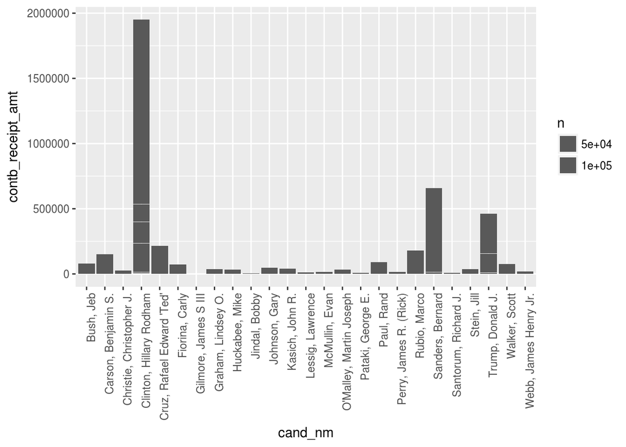

```
## # A tibble: 6 x 3
##   cand_nm                   num_support sum_support
##   <fctr>                          <int>       <dbl>
## 1 Clinton, Hillary Rodham        681518    95187058
## 2 Sanders, Bernard               404069    20679154
## 3 Trump, Donald J.                83741    14371373
## 4 Cruz, Rafael Edward 'Ted'       55914     7026960
## 5 Rubio, Marco                    13137     6434771
## 6 Bush, Jeb                        2982     3499582
```

Looking at the bar chart and the summary table, I can’t say about the top four most supported candidate; their order is the same.

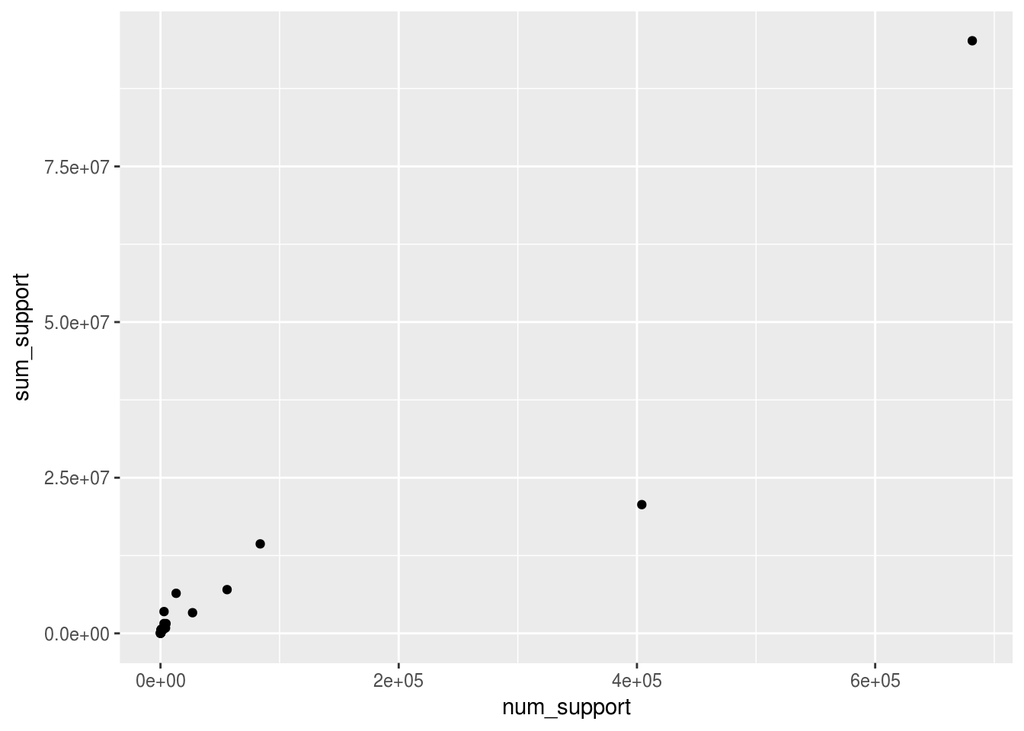

Looking at the scatterplot, we can recognize two definite and one more potential outlier. I searched for the names, and I found that these points are outliers, but with the good meaning. They were the most supported candidates. This finding is in harmony with my histograms.

Another finding is that the points almost lie on a straight line which would mean that the number of contribution and the overall sum correlates to each other.

```
## [1] 0.9413853
```

Another finding is that the points almost lie on a straight line which would mean that the number of contribution and the overall sum correlates to each other. The value of the correlation coefficient strengthens my theory.

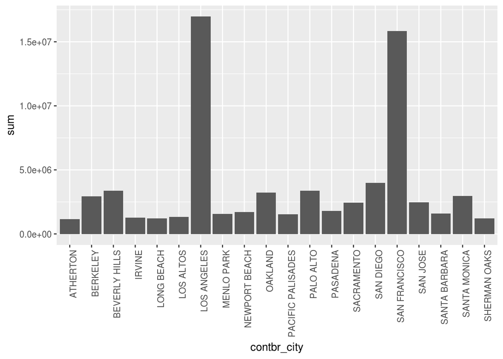

Because I have 2517 cities in my dataset, I couldn’t plot their data because the bars were too narrow. I handled this issue by selecting only the top 20 cities according to sum of the contribution made from there.

From that plot I can see, that there are two cities which have much more support than the others. After displaying the exact values we can see these top contributor cities.

```
## # A tibble: 10 x 3
##    contbr_city        sum  ratio
##    <fctr>           <dbl>  <dbl>
##  1 LOS ANGELES   16986730 0.107
##  2 SAN FRANCISCO 15851158 0.0999
##  3 SAN DIEGO      3996087 0.0252
##  4 PALO ALTO      3384997 0.0213
##  5 BEVERLY HILLS  3383396 0.0213
##  6 OAKLAND        3224293 0.0203
##  7 SANTA MONICA   2963744 0.0187
##  8 BERKELEY       2928039 0.0185
##  9 SAN JOSE       2466185 0.0155
## 10 SACRAMENTO     2435487 0.0154
```

I was curious about the money collected by people from a specific occupation. I have a hypothesis, that a lot of retiree and unemployed people contributed to the campaign, I would think that they could not donate so much money personally. That’s why I compared the average amount of a single donation by occupation.

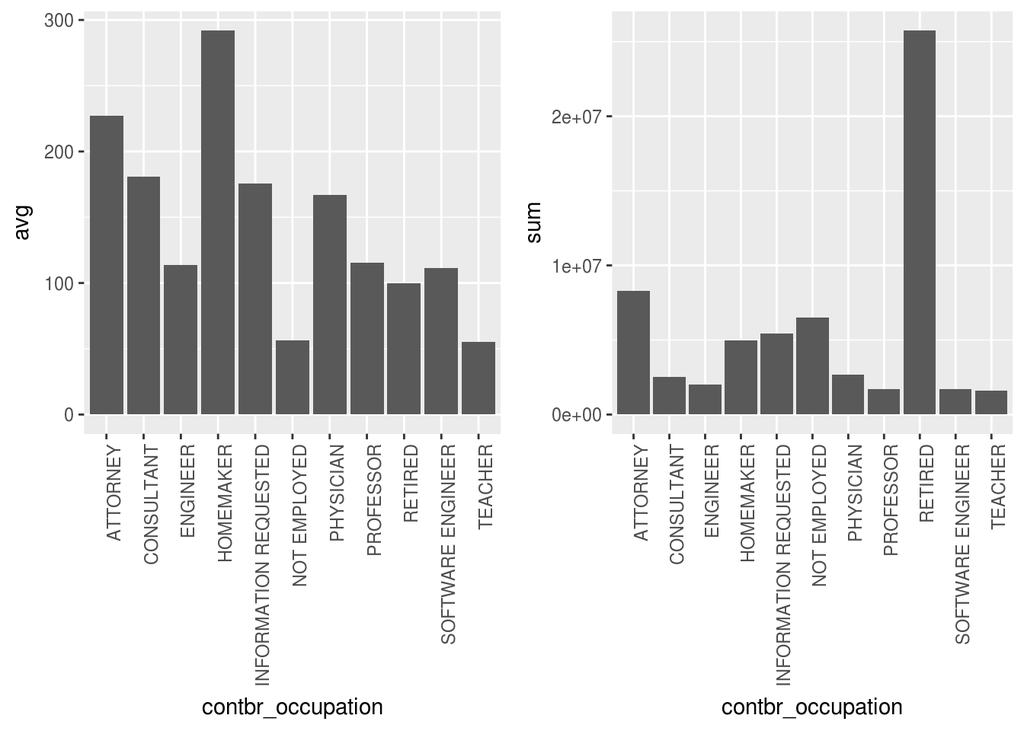

We can see that - as I expected - retirees raised the largest amount. But the average individual contribution of retirees was quite low - only the teachers and unemployed people have lower average support.

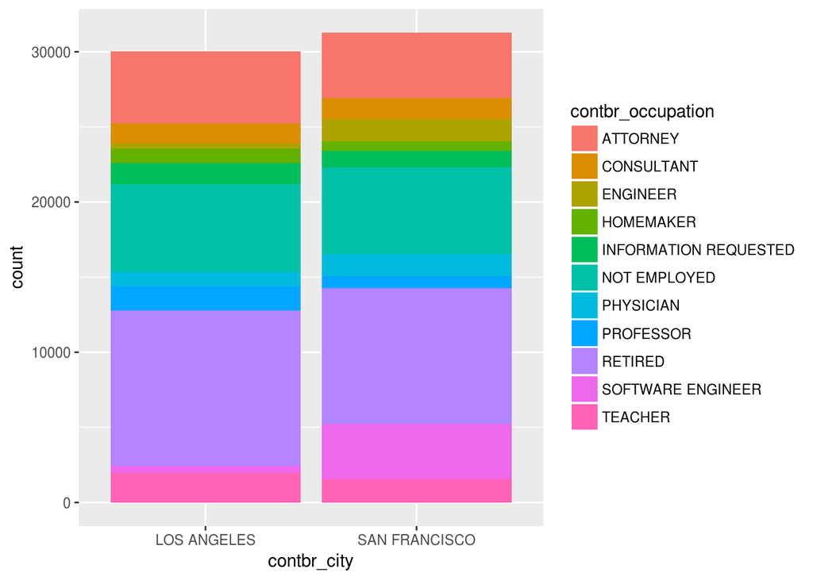

```
## # A tibble: 11 x 3
##    contbr_occupation     `LOS ANGELES` `SAN FRANCISCO`
##  * <fctr>                        <int>           <int>
##  1 ATTORNEY                       4786            4347
##  2 CONSULTANT                     1313            1422
##  3 ENGINEER                        371            1484
##  4 HOMEMAKER                       964             659
##  5 INFORMATION REQUESTED          1409            1091
##  6 NOT EMPLOYED                   5833            5763
##  7 PHYSICIAN                       937            1440
##  8 PROFESSOR                      1633             827
##  9 RETIRED                       10319            9063
## 10 SOFTWARE ENGINEER               497            3657
## 11 TEACHER                        1956            1541
```

Just from curiosity, I plotted the ratio of the top 11 occupations for the two most contributing cities.

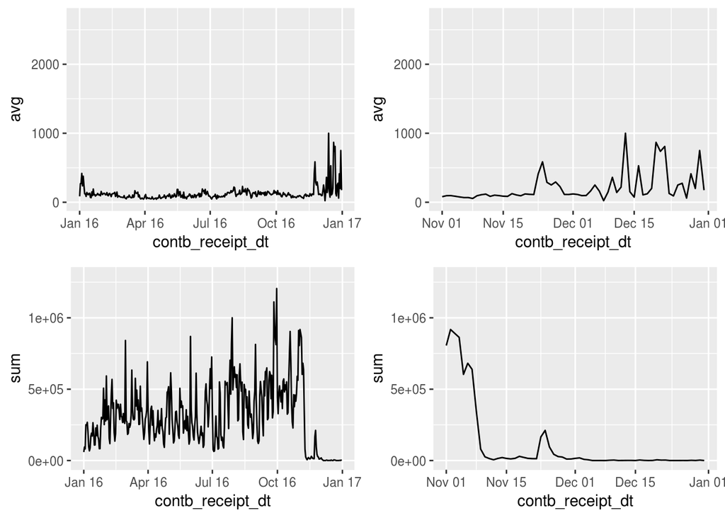

On the plots above we can see how average amount and sum of contributions per day changed in 2016. It is striking that the average number of contribution remained almost the same during the year, but after November 15 some large amount support came in. In contrast, the sum of all contribution on a given day was on a given level, raised in October and fell around 8th of November.

# Bivariate Analysis

### Talk about some of the relationships you observed in this part of the investigation. How did the feature(s) of interest vary with other features in the dataset?

In general, the number and the sum of all contribution were connected to each other, but not in all cases.

- The number and sum of all support what each candidate received correlated strongly with each other (r = 0.94).
- However, the retirees made a large number of donation and therefore the cumulative contribution was very high, the average amount per contribution was very low.
- And finally, Los Angeles and San Francisco were those cities from which the largest amount came. These two city has almost 20% of all contributions. The next two cities were San Diego and Palo Alto but with a much less amount.

### Did you observe any interesting relationships between the other features (not the main feature(s) of interest)?

# Multivariate Plots Section

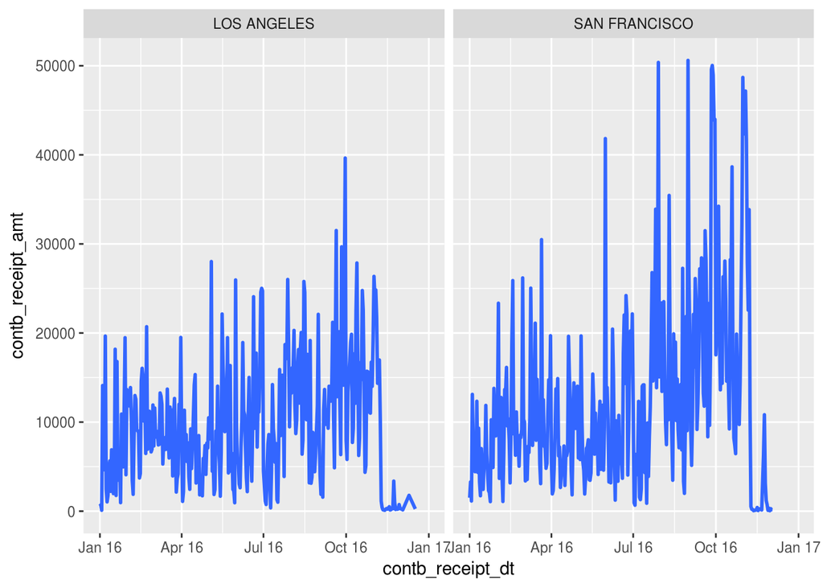

First, I created two plots about the change of the sum of contribution over time in Los Angeles and San Francisco. On this large-scale figure, I can see that San Francisco contributed more in the Summer of 2016 than Los Angeles.

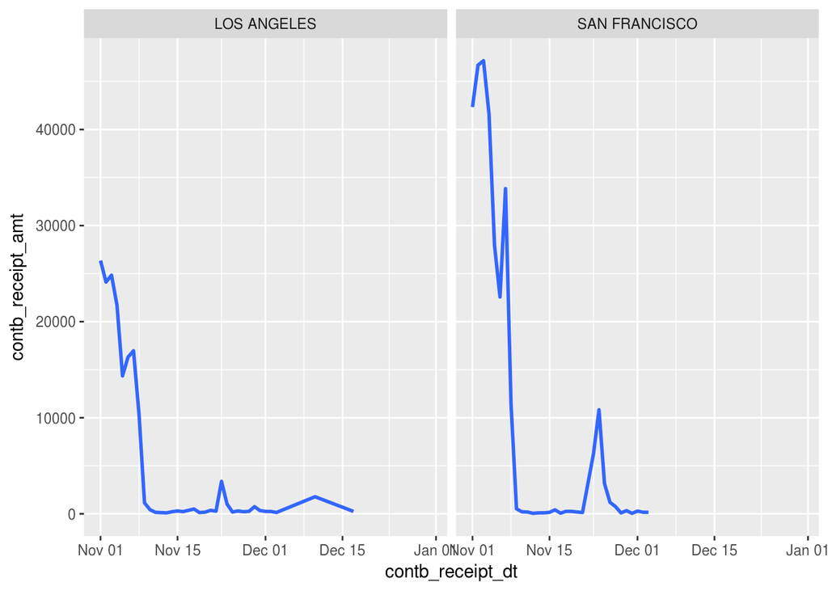

If we zoom into the end of the year, the finding becomes stronger: people in San Francisco contributed almost two times more money than people from Los Angeles. However, the trend is the same: high amount before the announcement of the result, then almost nothing. Finally, a small peak around November 20.

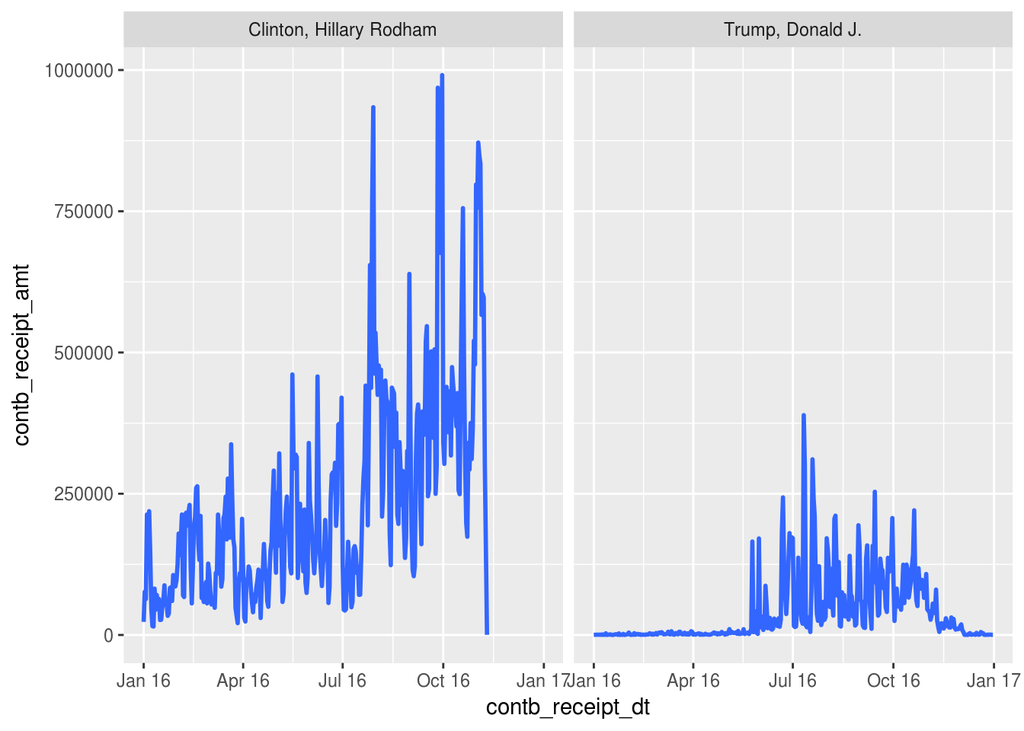

After plotting the amount of support in the year of election (2016) for the two finalist (Hillary Clinton and Donald Trump) I realized some striking difference:

- Hillary Clinton received higher amount of support almost always over the year
- Support of Hillary Clinton has an increasing trend, DT only increased in the summer, but the trend is constant

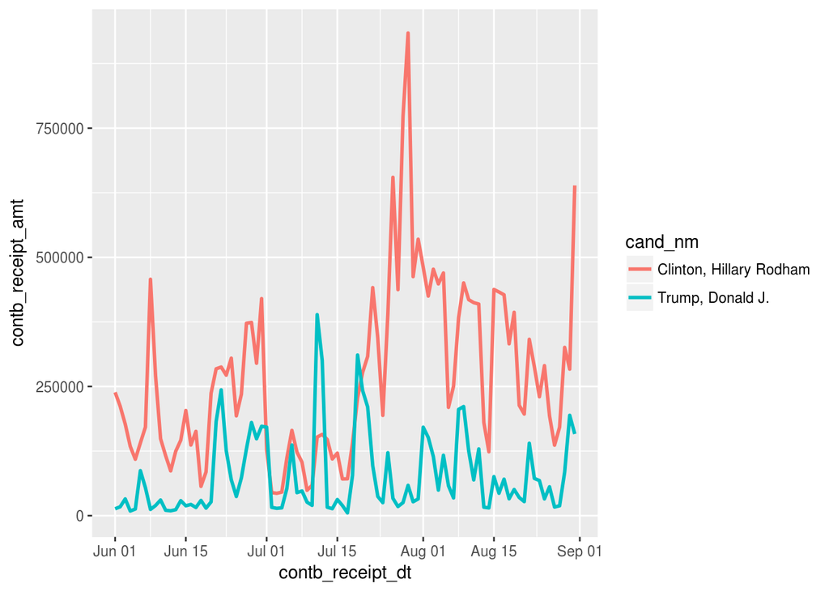

On the annual plot I could see a relatively large fall in the support of HC which happened in July, 2016. Interestingly, this was that time when DT has a small peak in his support. Drawing the two plots on each other, I saw that this coincided.

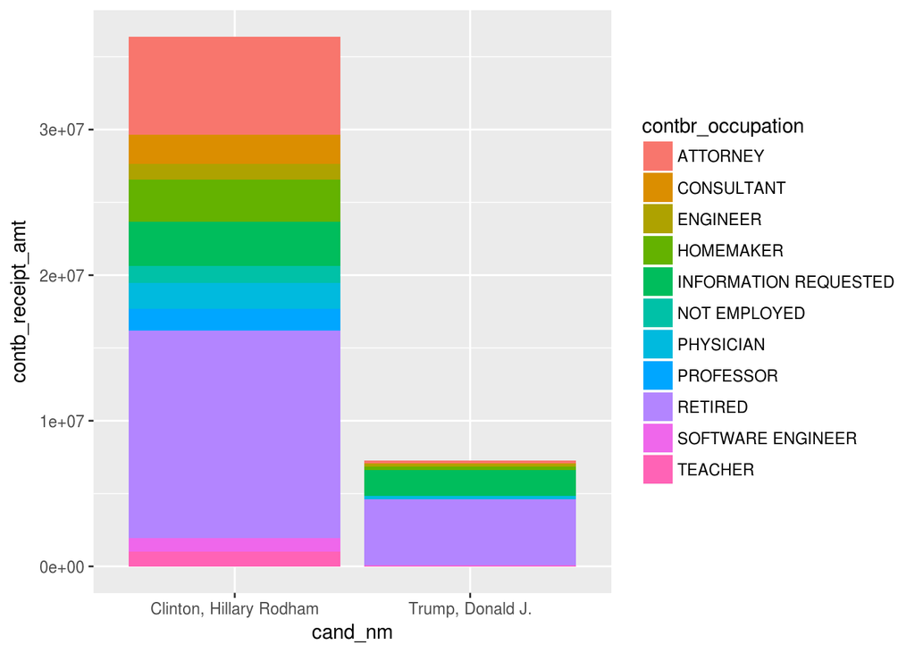

```
## # A tibble: 11 x 3
##    contbr_occupation     `Clinton, Hillary Rodham` `Trump, Donald J.`
##  * <fctr>                                    <dbl>              <dbl>
##  1 ATTORNEY                                6734465             186358
##  2 CONSULTANT                              2016156              71700
##  3 ENGINEER                                1069340             182035
##  4 HOMEMAKER                               2884460             224735
##  5 INFORMATION REQUESTED                   3061939            1770077
##  6 NOT EMPLOYED                            1164074              22551
##  7 PHYSICIAN                               1797183             193054
##  8 PROFESSOR                               1453351              13088
##  9 RETIRED                                14272378            4544368
## 10 SOFTWARE ENGINEER                        920762              32098
## 11 TEACHER                                 1021944              38844
```

When I plotted the amount given to each candidate grouped by occupation, a new interesting fact appeared: Donald Trump was supported with a noticeable amount only by retirees and people with unknown occupation. The other 9 occupation category gave him a lot less support. In the case of the other candidate, besides the retirees, attorneys gave a huge support to her (almost half of the sum given by retirees).

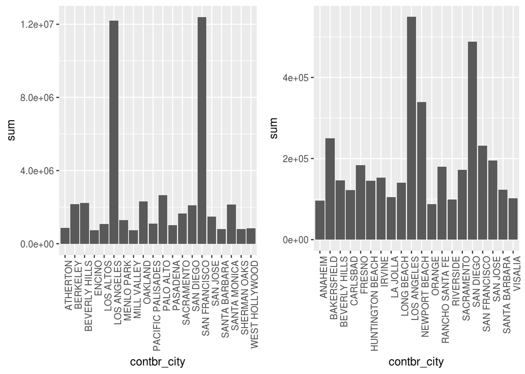

I collected the contributed amount grouped by cities for the two finalists, then I plotted the top 20 from these values. Hillary Clinton received the most contribution from Los Angeles and San Francisco. However, Donald Trump received most of his support from LA too, but the third and second cities were San Diego and Newport Beach. San Francisco was only on the 5th place after Bakersfield. Another thing what I noticed is that the contribution of Donald Trump is more evenly distributed among the top 20 cities than Hillary’s.

# Multivariate Analysis

### Talk about some of the relationships you observed in this part of the investigation. Were there features that strengthened each other in terms of looking at your feature(s) of interest?

Amount of support for the two candidates arrived mainly from different cities. Both candidates got a large amount of support from Los Angeles, but Hillary Clinton received a lot of support from San Francisco too, but Donald Trump got much more from San Diego and Newport Beach.

Hillary Clinton received almost every day in 2016 more support than the other candidate, and her daily support increased over time. On the other hand, Donald Trump received virtually nothing until the Summer of 2016, and from that time received lower daily support compared to his opponent.

In July 2016 something could happen because Hillary Clinton’s support decreased steeply and for a short time she received less donation.

### Were there any interesting or surprising interactions between features?

Surprising facts were to me all of the unbalanced ratio, like

- Large number of attorneys supported Hillary Clinton.
- People from Los Angeles were very active at supporting both candidates.
- Retirees supported both candidates with a high amount.
- Newport Beach and Bakersfield gave a proportionally large amount of donation to Donald Trump, while these cities weren’t in the 20 top supporter city of H. Clinton

# Final Plots and Summary

### Plot One

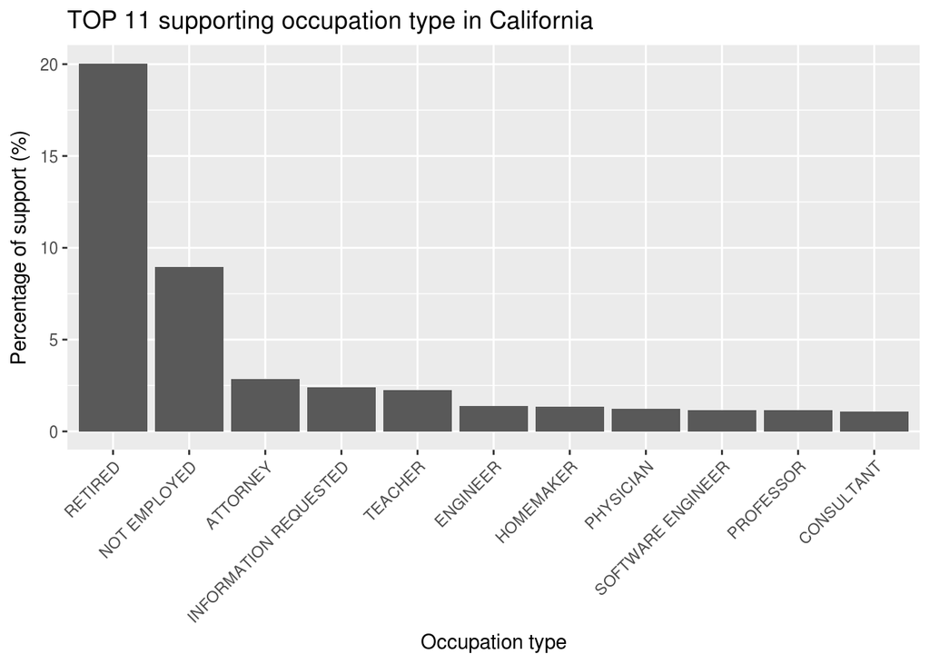

### Description One

20% of the support came from retirees in California, the second most support (almost 10%) came from unemployed people. It is a bit surprising to me because I would think this two social class aren’t in good financial condition.

### Plot Two

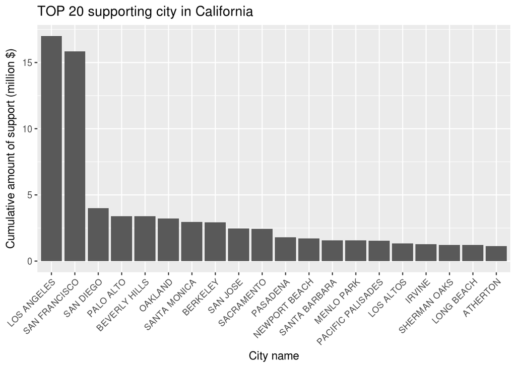

### Description Two

Los Angeles and San Francisco were the two most contributing cities in California. I expected this fact, but not to this extent.

### Plot Three

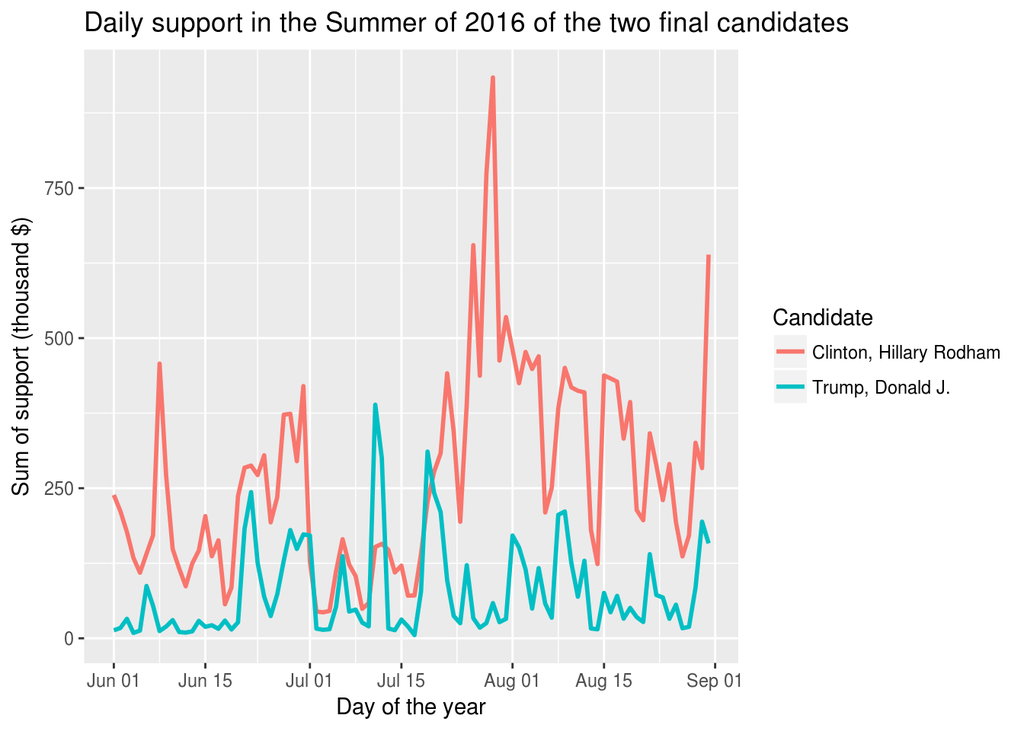

# Reflection

This task was a bit challenging to me because I am interested in politics, but I’m not familiar with the election system of the USA. We could hear some news during the campaign, and I was curious about whether the findings in support data are in harmony with what I heard? (I found, yes.)

My greatest challenge was to handle long-tailed distributions. I am quite a visual type when it comes to data, but I can not visualize 2000+ value on a bar chart. Therefore I set up limits what will I examine. These limits resulted in a manageable number of values.

I think I could find some interesting trends and connections in the dataset, but there is room for improvement. For example:

- I can fit some predictive model to the data.
- I could use NLP tools to analyze notes on the check.
- I could spread the analysis to other states.
- I could correlate external data (public opinion research) with the support data.